# Evaluation of a Beta-Blocker–Edema–Loop Diuretic Prescribing Cascade: A Prescription Sequence Symmetry Analysis | American Journal of Hypertension | Oxford Academic

[figure not shown]

[figure not shown]

[figure not shown]

Volume 35

Issue 7

July 2022

### Article Contents

Journal Article

# Evaluation of a Beta-Blocker–Edema–Loop Diuretic Prescribing Cascade: A Prescription Sequence Symmetry Analysis

Scott Martin Vouri, Earl J Morris, Xinyi Jiang, Ann-Kathrin Hofer, Stephan Schmidt, Carl Pepine, Almut G Winterstein, Steven M Smith

*American Journal of Hypertension*, Volume 35, Issue 7, July 2022, Pages 601–609, https://doi.org/10.1093/ajh/hpac013

Published:

01 February 2022

Article history

## Abstract

BACKGROUND

Drug-related adverse events associated with antihypertensive therapy may result in subsequent prescribing of other potentially harmful medications, known as prescribing cascades. The aim of this study was to assess the magnitude and characteristics of a beta-blocker–edema–loop diuretic prescribing cascade.

METHODS

A prescription sequence symmetry analysis was used to assess loop diuretic initiation before and after initiation of beta-blockers among patients 20 years or older without heart failure, atrial fibrillation, other arrythmias, or use of calcium channel blocker within a U.S. private insurance claims database (2005–2018). The temporality of loop diuretic initiation relative to a beta-blocker or negative control (renin-angiotensin system blocker) initiation was tabulated. Secular trend-adjusted sequence ratios (aSRs) with 95% confidence intervals (CIs) compared the initiation of loop diuretic 90 days before and after initiation of beta-blockers.

RESULTS

Among 988,675 beta-blocker initiators, 9,489 patients initiated a new loop diuretic prescription 90 days after and 5,245 patients before beta-blocker initiation, resulting in an aSR of 1.78 (95% CI, 1.72–1.84). An estimated 1.72 beta-blocker initiators per 100 patient-years experienced the prescribing cascade in the first 90 days. The aSR was disproportionately higher among older adults (aSR 1.97), men (aSR 2.25), and patients who initiated metoprolol tartrate (aSR 2.48), labetalol (aSR 2.18), or metoprolol succinate (aSR 2.11). Negative control results (aSR 1.09, 95% CI, 1.05–1.13) generally corroborated our findings, but suggested modest within-person time-varying confounding.

CONCLUSIONS

We observed excess use of loop diuretics following beta-blocker initiation that was only partially explained by secular trends or hypertension progression.

Graphical Abstract

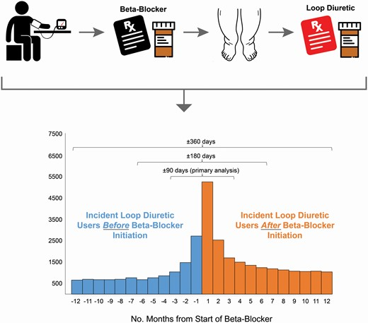

beta-blockers, blood pressure, drug-induced adverse events, hypertension, loop diuretics, prescribing cascades

Subject

[Epidemiology](https://academic.oup.com/ajh/search-results?page=1&tax=ajhype/ajh-08)

Issue Section:

Treatment

Beta-blockers are a common treatment option for hypertension, arrhythmias, acute ischemic syndromes, or heart failure, with demonstrated benefits on morbidity and mortality in secondary prevention.<sup>1</sup> Their use is ubiquitous, with over a third of U.S. adults receiving a beta-blocker regimen in 2013–2016.<sup>2</sup> However, these medications can be associated with adverse events that reduce quality of life and/or have other serious consequences.<sup>3</sup> Several of these adverse events are well-known, such as bradycardia and fatigue, although lesser-known events, such as peripheral edema, can also contribute to patient dissatisfaction.

Prior randomized-controlled trials suggest a higher risk for peripheral edema in patients assigned to beta-blocker treatment when compared to patients assigned to placebo.<sup>4–6</sup> This relatively high incidence contrasts with common unawareness about this particular side effect potential, positioning beta-blockers as candidates for prescribing cascades, which occur when a drug-induced adverse event is treated with a new medication instead of deprescribing the offending medication and using an alternative.<sup>7</sup> Such prescribing cascades contribute to worsening polypharmacy with the potential for unnecessary downstream consequences such as additional adverse events and increased healthcare utilization.<sup>8,9</sup> In the case of beta-blocker-induced edema, in the absence of congestive heart failure, atrial fibrillation, or arrhythmias, continuation of the beta-blocker and addition of a loop diuretic may constitute a prescribing cascade.<sup>8</sup>

The extent to which beta-blocker-induced peripheral edema results in excess use of a loop diuretic has not been explored. Therefore, we evaluated the risk for this prescribing cascade with beta-blockers, overall and for individual agents, among a large sample of commercially insured patients in the United States.

## METHODS

### Study Design

A prescription sequence symmetry analysis (PSSA) was used to assess for temporal patterns of loop diuretic initiation relative to the initial beta-blocker prescription. This pharmacovigilance approach, using a case-only design, has produced similar results when compared with a cohort study design for other antihypertensive prescribing cascades.<sup>8,10</sup> A PSSA works by first identifying patients who initiated the medication suspected of causing a drug-induced adverse event (*index* drug, i.e., a beta-blocker) and, among these patients, selects everyone who initiated a medication potentially used to treat the adverse event (*marker* drug, i.e., a loop diuretic) within a specified *exposure window* (±90 days of index drug initiation).<sup>11</sup> Using the PSSA, pre-index drug initiation of marker drugs serves as a control in relationship to post-index drug initiation of marker drugs.<sup>12</sup> Therefore, if a similar number of patients initiate the marker drug before and after the index drug, then no prescribing cascade signal is observed, and the resulting graphical representation of prescription sequence appears symmetrical. However, in the case of a positive prescribing cascade signal, the marker drug is initiated more often after the index drug compared to before resulting in an asymmetric pattern, which can be quantified (see Statistical Analysis). Additionally, a benefit of the PSSA, when compared to a traditional cohort study, is that time-invariant confounders (e.g., age, sex, comorbidities) are inherently adjusted, reducing the need for complex multivariable analyses.<sup>13</sup>

### Data source

IBM MarketScan Commercial and Medicare Supplemental Claims data from January 2005 to December 2018 were used for the presented analyses. These U.S. nationwide administrative claims databases contain longitudinal, person-level information of healthcare utilization across all settings, including outpatient visits, hospital stays, and pharmacy dispensings. The study population includes employees and their dependents, and retirees with employer-sponsored or government Medicare supplemental insurance. The study was exempted from review by the University of Florida institutional review board because of its use of deidentified data. We used the Strengthening the Reporting of Observational Studies in Epidemiology (STROBE) reporting guideline to ensure appropriate reporting.<sup>14</sup>

### Study population

Beta-blocker *initiators* were identified among patients aged ≥20 years who had at least 720 days of continuous enrollment before and 360 days after their initial beta-blocker claim. Patients with an inpatient or outpatient diagnosis of heart failure within 720 days before and 360 days after the initial beta-blocker claim were excluded since use of a loop diuretic for heart failure–related fluid overload would not be considered a prescribing cascade (Supplementary Appendix 1). Additionally, patients initiated on a calcium channel blocker within 720 days before and 360 days after beta-blocker initiation were excluded as these agents are associated with edema and can cause a similar prescribing cascade.<sup>8,10</sup> Finally, patients with arrythmias (Supplementary Appendix 1) were excluded since there are few alternatives for rate control among patients who are unable to utilize a calcium channel blocker resulting in the risk versus benefit assessment of a beta-blocker prescribing cascade and arrythmias may be independently associated with edema.<sup>15</sup> We identified the *initial loop diuretic claim* (e.g., furosemide, bumetanide, torsemide, ethacrynic acid) within 90 days before or after the initial beta-blocker claim, and excluded patients initiating both index and marker drugs on the same date.<sup>16,17</sup> We utilized a 90-day exposure window as the primary analysis to minimize within-patient time-varying bias (i.e., loop diuretics are generally used later in an antihypertensive regimen, suggesting hypertension progression, which could create a similar asymmetric pattern not attributable to a prescribing cascade).<sup>18</sup> We performed sensitivity analyses using 180-day and 360-day exposure windows to assess for the potential of delayed diagnosis (and subsequent treatment) for drug-induced edema.

We performed stratified analyses among subpopulations based on age (<65 and ≥65 years), sex, calendar year, initial beta-blocker medication (acebutolol, atenolol, bisoprolol, metoprolol tartrate, metoprolol succinate, nadolol, nebivolol, propranolol, carvedilol, labetalol), and diagnosis of chronic kidney disease (Supplementary Appendix 1).

To account for potential false positive signals related to loop diuretic use as subsequent line therapy for additional blood pressure-lowering (e.g., within-person time-varying bias), we performed additional analyses using negative control index drugs (angiotensin-converting enzyme [ACE] inhibitor or angiotensin receptor blocker [ARB]) not known to cause edema, in place of beta-blockers.<sup>8,18</sup> This negative control analysis was in addition to utilizing the pre-index drug utilization of the marker drug (i.e., pre-beta-blocker initiation of loop diuretics) as the control since this control only accounts for time-invariant confounding. More specifically in these negative control analyses, we restricted the cohort to patients without a diagnosis of heart failure or arrythmia who were initiated on either an ACE inhibitor or ARB as the index drug, again with loop diuretics as the marker drug. This analysis excluded patients initiating a beta-blocker or calcium channel blocker within ±90 days of the index ACE inhibitor or ARB. We performed similar stratified and sensitivity analyses for the negative control as in the primary analyses.